# rp100

The purpose of this script is (a) to find out which parameters produce the best-fit LISFLOOD model of the 100-year floodplain in Sonoma County, and (b) to determine which parameters the results are sensitive to.

```r
## setup information
source('_data/setup.R')

## set parallel backend
num_cores <- 5

## load location information
load('_data/lisflood/dem.Rdata')
load('_data/aoi/aoi.Rdata')

## load required packages
require(ggpubr)
require(grid)
require(gridExtra)
require(gt)

## set random seed for reproducibility
set.seed(7395)
```

# 1 Generate LISFLOOD simulations

The first goal is to define the parameters of interest and calculate inundation maps for those sets of parameters. We generate 1,000 Latin hypercube samples of 20 uniform variables and transform them to match the distributions of the parameters under consideration. We run the script $generate\_files.sh$ create .bci, .bdy, .n.asc, and .par files based on these samples. The samples and associated files are then run through LISFLOOD to produce 1,000 inundation maps using the script $run\_lisflood.sh$. All of these files can be found in the rp100/sherlock folder. An explanation of the various files and the simulation process can be found in the LISFLOOD documentation.

# 2 Determine accuracy metrics

The next goal is to determine some measure of accuracy, i.e. how well the LISFLOOD simulations are able to recreate the “true” case. In this case the data used as a source of truth is the Federal Emergency Management Program (FEMA) 100-year floodplain as downloaded from the National Flood Hazard Layer (NFHL). This is a fairly standard practice for validating flood models, such as the one used by First Street Foundation (Wing et al., 2020). We estimated the peak inflow at USGS gage 11463500 to be $Q_p = 112,000 \; cfs = 3,171 \; m^3/s$ using the USGS StreamStats tool. This value is fixed, and several other parameters are varied to find the best-fit LISFLOOD model. We consider twenty different parameters that can be changed in the LISFLOOD model to modify the resulting inundation map. A table of these parameters and the values considered for each parameter is included below.

## 2.1 Compute accuracy metrics (critical success ratio & Hausdorff distance) for each inundation map

```r
## load NFHL "observed" data
load('_data/NFHL/NFHL.Rdata')

## load simulated data
sim.list <- list.files('_sensitivity/rp100/sherlock/results') %>%
  gsub('rpflow', '', .) %>% gsub('.max', '', .) %>% toNumber

## write a function to generate the reduced confusion matrix
confusion <- function(obs, sim) {
  ifelse(obs > 0 & sim > 0, 0,
         ifelse(obs > 0 & sim <= 0, -1,
                ifelse(obs <= 0 & sim > 0, 1, NA)))
}

## write a function to collapse simulation into wet/dry binary
binary <- function(x) {
  mat <- as.matrix(x)
  mat <- ifelse(is.na(mat[]), 0, ifelse(mat[]>0, 1, 0))
  return(mat)
}

# ## compute accuracy metrics
# start <- Sys.time()
# # pb <- txtProgressBar(min = 0, max = length(sim.list), style = 3)
# cl <- parallel::makeCluster(num_cores)
# registerDoSNOW(cl)
# accuracy <-
#   foreach(i = sim.list, .inorder = FALSE,
#     .combine = 'rbind', .export = c('confusion', 'binary'),
#     # .options.snow = list(progress = function(n) setTxtProgressBar(pb, n)),
#     .packages = c('raster', 'dplyr', 'pracma')) %dopar% {
#       sim <- paste0('_sensitivity/rp100/sherlock/results/rpflow', i, '.max') %>%
#         raster %>% overlay(dem.hydro, fun = function(x,y) ifelse(is.na(y), NA, x))
#
#       ## calculate confusion matrix statistics
#       tb <- overlay(obs, sim, fun = confusion)[] %>% table
#
#       ## calculate Hausdorff distance
#       hd <- hausdorff_dist(binary(sim), as.matrix(obs))
#
#       ## save metrics as dataframe
#       c(id = i,
#         hitrate = unname(tb['0'] / (tb['-1'] + tb['0'])),
#         falsalarm = unname(tb['1'] / (tb['0'] + tb['1'])),
#         fstat = unname(tb['0'] / sum(tb)),
#         bias = unname(tb['1'] / tb['-1']),
#         hausdorff = hd)
#     }
# stopCluster(cl)
# Sys.time() - start
#
# ## save checkpoint
# save(accuracy, file = '_sensitivity/rp100/checkpoints/accuracy.Rdata')
load('_sensitivity/rp100/checkpoints/accuracy.Rdata')

## join to samples dataframe
samples.rp100 <- read.table('_sensitivity/rp100/sherlock/samples_rp100.txt', header = TRUE)
vars <- names(samples.rp100)
samples.rp100 <- samples.rp100 %>%
  mutate(id = 1:nrow(.)) %>%
  left_join(data.frame(accuracy), by = 'id')
```

LISFLOOD Sensitivity Testing

| Parameters Name | Parameters Description | Values<sup>1</sup> Min | Values<sup>1</sup> Max | Values<sup>1</sup> Default |
| --- | --- | --- | --- | --- |
| Floodplain Roughness Parameters |  |  |  |  |
| 95 | Emergent Herbaceous Wetlands | 0.035 | 0.12 | 0.045 |
| 90 | Woody Wetlands | 0.045 | 0.15 | 0.070 |
| 82 | Cultivated Crops | 0.020 | 0.10 | 0.050 |
| 81 | Pasture/Hay | 0.025 | 0.090 | 0.045 |
| 71 | Grassland/Herbaceous | 0.025 | 0.070 | 0.040 |
| 52 | Shrub/Scrub | 0.050 | 0.16 | 0.050 |
| 43 | Mixed Forest | 0.080 | 0.20 | 0.12 |
| 42 | Evergreen Forest | 0.080 | 0.18 | 0.15 |
| 41 | Deciduous Forest | 0.10 | 0.20 | 0.10 |
| 31 | Barren Land | 0.023 | 0.10 | 0.030 |
| 24 | Developed - High Intensity | 0.12 | 0.20 | 0.15 |
| 23 | Developed - Medium Intensity | 0.060 | 0.16 | 0.12 |
| 22 | Developed - Low Intensity | 0.060 | 0.12 | 0.080 |
| 21 | Developed - Open Space | 0.030 | 0.090 | 0.035 |
| 11 | Open Water | 0.020 | 0.050 | 0.035 |
| Channel Parameters |  |  |  |  |
| SGCn | Channel Roughness Parameter | 0.015 | 0.075 | 0.035 |
| SGCp | Channel Depth Parameter | 0.69 | 0.82 | 0.76 |
| SGCr | Channel Depth Parameter | 0.050 | 0.50 | 0.30 |
| Hydrograph Parameters |  |  |  |  |
| tp | Time to Peak Flow (hrs) | 1.0 | 80 | 24 |
| m | Hydrograph Shape Parameter | 0 | 10 | 4.0 |

<sup>*1*</sup> All parameters are assumed to be uniformly distributed between min and max.

# 3 Attempt model falsification

The third goal is to attempt model falsification. This process helps us to understand whether or not the parameter ranges we have chosen are reasonable, and whether the LISFLOOD model with the chosen parameter ranges is even capable of reproducing the FEMA NFHL under best-case circumstances. We do this with multi-dimensional scaling (MDS). We create a matrix where the “distance” (inverse of accuracy) is measured between every pair of simulations, then we reduce the dimensionality of that matrix so that it can be displayed on a 2D plot. If the point representing the FEMA NFHL map falls outside of the point cloud representing the suite of LISFLOOD simulations, then the parameter ranges and the model are such that it will never be able to perfectly reproduce the “true” case, and the model is falsified. If the point representing the FEMA NFHL map falls within the simulation point cloud then the model is deemed acceptable.

As mentioned in the previous section, we have 1,000 LISFLOOD simulations. There is substantial similarity between the inundation maps for these simulations, and creating a $1000 \times 1000$ distance matrix is computationally expensive. Therefore we first use k-means clustering to identify 100 representative simulations and perform the MDS falsification process with that reduced set.

## 3.1 Cluster LISFLOOD simulations to reduce computational demand

```r
# ## run k-means clustering algorithm
n <- 100
# samples.k <- samples.rp100 %>%
#   filter(complete.cases(.)) %>%
#   mutate(bias.odds = bias / (1 + bias),
#          hausdorff = hausdorff/max(hausdorff)) %>%
#   dplyr::select(hitrate, falsalarm, fstat, bias.odds, hausdorff) %>%
#   kmeans(centers = n, iter.max = 1e3, nstart = 100, trace = FALSE)
# samples.rp100$mds.cluster[complete.cases(samples.rp100)] <- samples.k$cluster
#
# ## find the best-fitting simulation within each cluster
# cluster.id <- samples.rp100 %>%
#   mutate(test = hausdorff/Max(hausdorff) + (1-fstat)) %>%
#   group_by(mds.cluster) %>%
#   summarize(id = id[which.min(test)], .groups = 'drop') %>% pull(id)
#
# ## save checkpoint
# save(samples.rp100, cluster.id, file = '_sensitivity/rp100/checkpoints/samples_cluster.Rdata')
load('_sensitivity/rp100/checkpoints/samples_cluster.Rdata')
```

## 3.2 Create distance matrix based on critical success ratio

```r
# ## generate matrix
# start <- Sys.time()
# # pb <- txtProgressBar(min = 0, max = n, style = 3)
# cl <- parallel::makeCluster(num_cores)
# registerDoSNOW(cl)
# fstat <-
#   foreach(i = 1:n,
#     .combine = 'rbind', .export = 'confusion',
#     # .options.snow = list(progress = function(n) setTxtProgressBar(pb, n)),
#     .packages = c('raster', 'dplyr', 'pracma', 'foreach')) %dopar% {
#       sim.i <- paste0('_sensitivity/rp100/sherlock/results/rpflow', cluster.id[i], '.max') %>%
#         raster %>% overlay(dem.hydro, fun = function(x,y) ifelse(is.na(y), NA, x))
#       foreach(j = 1:n, .combine = 'c') %do% {
#         if (i >= j) 0 else {
#           sim.j <- paste0('_sensitivity/rp100/sherlock/results/rpflow', cluster.id[j], '.max') %>%
#             raster %>% overlay(dem.hydro, fun = function(x,y) ifelse(is.na(y), NA, x))
#           tb <- overlay(sim.i, sim.j, fun = confusion)[] %>% table
#           1 - tb['0']/sum(tb)
#         }
#       }
#     }
# stopCluster(cl)
# Sys.time() - start
#
# ## add "observed" NFHL point
# fstat <- fstat %>%
#   cbind(1-samples.rp100$fstat[cluster.id]) %>%
#   rbind(rep(0, n+1))
#
# ## format matrix for MDS
# fstat <- fstat + t(fstat)
#
# ## save checkpoint
# save(fstat, file = '_sensitivity/rp100/checkpoints/fstat.Rdata')
load('_sensitivity/rp100/checkpoints/fstat.Rdata')
```

## 3.3 Create distance matrix based on Hausdorff distance

```r
# ## generate matrix
# start <- Sys.time()
# # pb <- txtProgressBar(min = 0, max = n, style = 3)
# cl <- parallel::makeCluster(num_cores)
# registerDoSNOW(cl)
# hausdorff <-
#   foreach(i = 1:n,
#     .combine = 'rbind', .export = 'binary',
#     # .options.snow = list(progress = function(n) setTxtProgressBar(pb, n)),
#     .packages = c('raster', 'dplyr', 'pracma', 'foreach')) %dopar% {
#       sim.i <- paste0('_sensitivity/rp100/sherlock/results/rpflow', cluster.id[i], '.max') %>%
#         raster %>% overlay(dem.hydro, fun = function(x,y) ifelse(is.na(y), NA, x))
#       foreach(j = 1:n, .combine = 'c') %do% {
#         if (i >= j) 0 else {
#           sim.j <- paste0('_sensitivity/rp100/sherlock/results/rpflow', cluster.id[j], '.max') %>%
#             raster %>% overlay(dem.hydro, fun = function(x,y) ifelse(is.na(y), NA, x))
#           hausdorff_dist(binary(sim.i), binary(sim.j))
#         }
#       }
#     }
# stopCluster(cl)
# Sys.time() - start
#
# ## add "observed" NFHL point
# hausdorff <- hausdorff %>%
#   cbind(samples.rp100$hausdorff[cluster.id]) %>%
#   rbind(rep(0, n+1))
#
# ## format matrix for MDS
# hausdorff <- hausdorff + t(hausdorff)
#
# ## save checkpoint
# save(hausdorff, file = '_sensitivity/rp100/checkpoints/hausdorff.Rdata')
load('_sensitivity/rp100/checkpoints/hausdorff.Rdata')
```

## 3.4 Perform multi-dimensional scaling (MDS) on distance matrices

```r
## compute MDS values
mds.fstat <- cmdscale(fstat, eig = TRUE, k = n/2)
mds.hd <- cmdscale(hausdorff, eig = TRUE, k = n/2)

## scale eigenvalues to represent % variance explained
mds.fstat$var <- abs(mds.fstat$eig)/sum(abs(mds.fstat$eig))
mds.hd$var <- abs(mds.hd$eig)/sum(abs(mds.hd$eig))

## determine how many dimensions it requires to get to 90% of variance explained
mds.fstat$dim90 <- min(which(cumsum(mds.fstat$var) > 0.9))
mds.hd$dim90 <- min(which(cumsum(mds.hd$var) > 0.9))
```

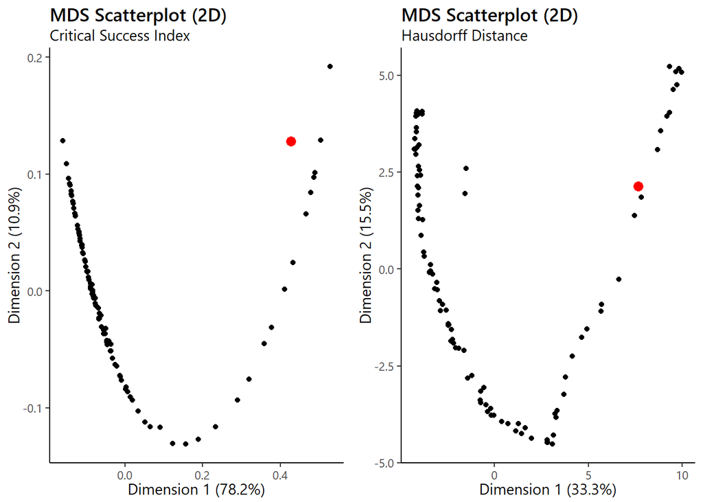

In the plots above, we see that the FEMA NFHL point falls within the range of and/or along the line of LISFLOOD simulations using both the critical success ratio and the Hausdorff distance as metrics. Therefore we are unable to falsify the model and we assume that the parameter ranges we have chosen are reasonable.

# 4 Examine parameter sensitivity

The next task to determine which of the twenty parameters of interest actually have a significant effect on the resulting inundation maps using regional sensitivity analysis (RSA). The RSA process is as follows:

- Use k-means clustering to divide the MDS sample space into a specified number of classes.
- For each parameter, look at the frequency distributions of the full sample set vs. the individual classes.
- Use a bootstrapped estimate to determine if the frequency distributions of the classes differ significantly $(\alpha = 0.05)$ from the frequency distribution of the full sample (i.e. measure the L1-norm between the two lines). If the value of the statistic $d$ is greater than 1 the parameter is assumed to be significant.

We use the Hausdorff MDS distance matrix for this analysis, and we repeat the RSA process for a variety of $k$ values. The results are shown in the plots below.

## 4.1 Write helper functions for regional sensitivity analysis (RSA)

```r
#### write RSA function ####

RSA <- function(k, plot = FALSE, data = FALSE) {
  # k: number of clusters to evaluate
  # plot: determines which diagnostic plots to output
        # (can be TRUE, FALSE, or any combination of c('k', 'var', 'rsa'))
  # data: determines whether to output the RSA hypothesis testing values

  ## perform k-means clustering on MDS distances
  kclust <-
    mds.hd$points[-(n+1), 1:mds.hd$dim90] %>%
    kmeans(centers = k, iter.max = 1000, nstart = 10)
  cluster.colors <- scico(palette = 'bamako', n = k+2)[2:(k+1)]

  ## attach MDS distances to parameter information
  df.cluster <- mds.hd$points[-(n+1), 1:2] %>%
    as.data.frame %>%
    setNames(c('x','y')) %>%
    mutate(id = cluster.id) %>%
    left_join(samples.rp100, by = 'id') %>%
    mutate(rsa.cluster = factor(kclust$cluster))

  ## generate 95% confidence intervals for every parameter & cluster
  cl <- parallel::makeCluster(num_cores)
  registerDoSNOW(cl)
  d <-
    foreach(cl = 1:k, .combine = 'rbind',
      .export = 'L1_boot', .packages = c('dplyr', 'pracma', 'foreach'), .inorder = FALSE) %:%
    foreach(var = vars, .combine = 'rbind', .inorder = FALSE) %dopar% {
      data.frame(
        cl = cl, var = var,
        d = L1_boot(df.cluster, 'rsa.cluster', cl, var, NA),
        d95 = L1_boot(df.cluster, 'rsa.cluster', cl, var) %>% quantile(0.95) %>% unname)
    }
  stopCluster(cl)

  ## standardize L1-norm coefficients
  d <- d %>% mutate(d.norm = d/d95, pass = d.norm>1)

  ## return results
  plot.RSA(plot, k, df.cluster, d, cluster.colors)
  if (data) df.cluster <<- df.cluster; return(d)
}
```

## 4.2 Run RSA for multiple values of k

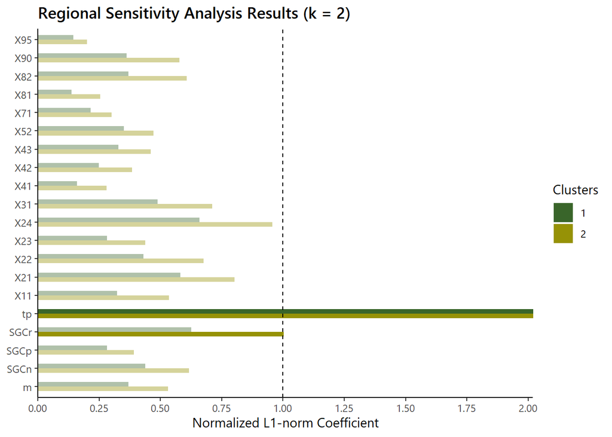

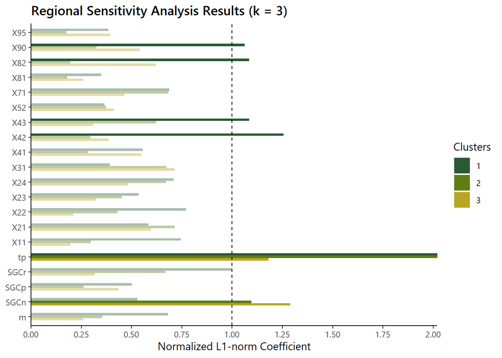

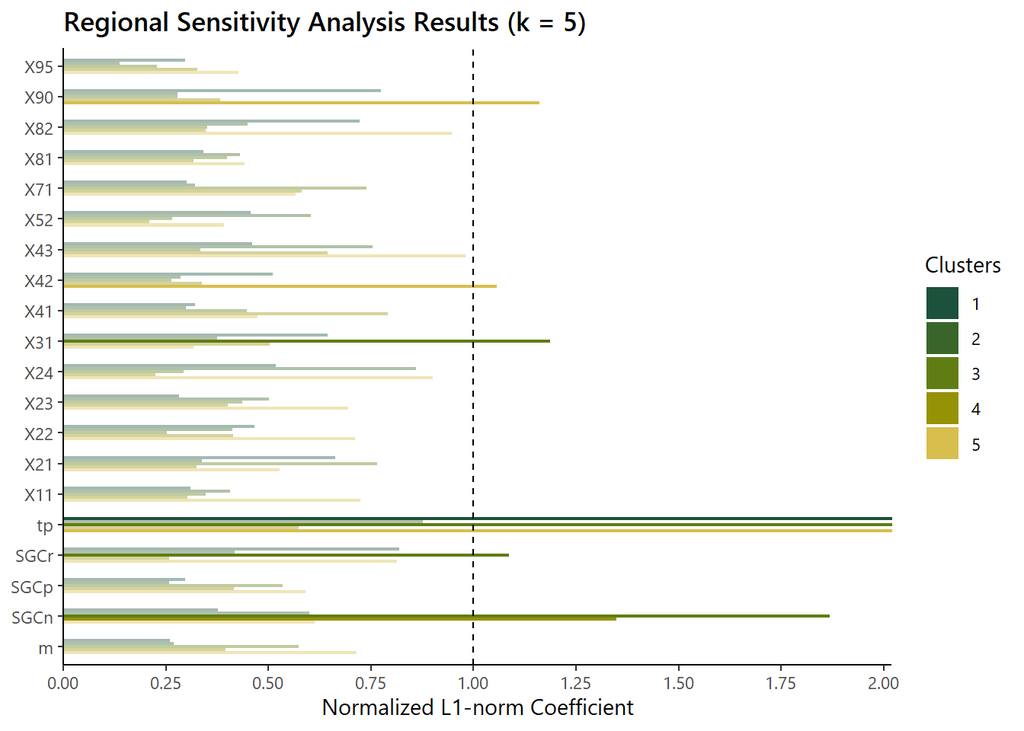

## 4.3 Test stability of RSA results

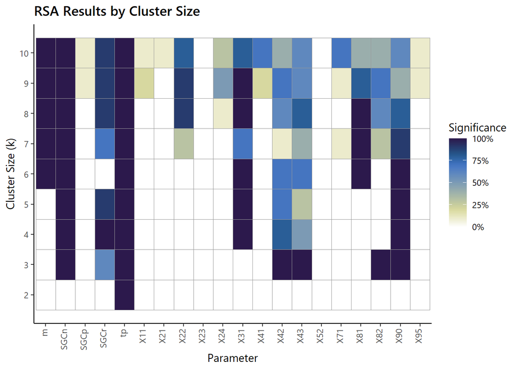

```r
# ## run RSA for k = 2:10, 10 times each
# start <- Sys.time()
# rsa.mc <- map(.x = 2:10,
#   .f = function(k) {
#     map(.x = 1:10, .f = ~RSA(k, data = TRUE) %>%
#           filter(pass) %>% pull(var) %>% unique)})
# Sys.time() - start
#
# ## save checkpoint
# save(rsa.mc, file = '_sensitivity/rp100/checkpoints/rsa_mc.Rdata')
load('_sensitivity/rp100/checkpoints/rsa_mc.Rdata')
```

The horizontal axis of this plot shows the twenty parameters under consideration. The vertical axis represents the cluster size $k$ for the RSA results, and the shading represents what percentage of runs found a certain variable to be significant at a given $k$ threshold. Choosing a significance threshold is a bit of a qualitative assessment. We notice that more parameters are found significant with increasing $k$ values, which makes sense because we are splitting the LISFLOOD runs into smaller and smaller buckets. Therefore we assign more importance to the parameters found to be significant at lower values of $k$.

The parameters deemed significant for further analysis are the following:

```
## [1] "X90"  "X82"  "X43"  "X42"  "X31"  "SGCn" "tp"   "SGCr"
```

We can also consider interactions between these parameters using distance-based generalized sensitivity analysis (DGSA) (Fenwick et al., 2014). DGSA clusters every parameter into high/low bucket and asks the following question: if we only consider the subset simulations with high values of parameter $A$, are the results still sensitive to parameter $B$? For every pair of parameters we would consider four permutations: $B_{high}|A_{high}$, $B_{high}|A_{low}$, $B_{low}|A_{high}$, and $B_{low}|A_{low}$. The maximum value of the $d$ statistic is taken from these four, and if $d_{max}>1$ then the interaction is assumed to be significant. DGSA also allows for asymmetric parameter interactions, i.e. $A|B$ does not necessarily equal $B|A$. The code to implement the DGSA algorithm and the resulting interactions plot are shown below.

## 4.4 Create distance-based generalized sensitivity analysis (DGSA) matrix

```r
#### create DGSA interactions matrix ####

# ## create 3 MDS clusters
# k <- 3
# df <- RSA(k, data = TRUE)
#
# ## find parameter interactions within those clusters
# start <- Sys.time()
# # pb <- txtProgressBar(min = 0, max = length(vars)^2, style = 3)
# cl <- parallel::makeCluster(num_cores)
# registerDoSNOW(cl)
# interactions <-
#   foreach (i = 1:length(vars), .combine = 'rbind',
#     # .options.snow = list(progress = function(n) setTxtProgressBar(pb, n)),
#     .export = 'L1_boot', .packages = c('pracma', 'tidyverse', 'foreach')) %:%
#   foreach (j = 1:length(vars), .combine = 'c') %dopar% {
#     if (i == j) {
#       ## fill in the main diagonal
#       df %>% filter(var == vars[i]) %>% pull(d.norm) %>% max
#
#     } else {
#       ## fill in the off-diagonals
#       foreach (cl = 1:k, .combine = 'max') %do% {
#         df.subset <- df.cluster %>% filter(rsa.cluster == cl)
#         df.subset$dgsa.cluster <-
#           kmeans(df.subset %>% pull(vars[j]),
#                  centers = 2, iter.max = 1000, nstart = 100)$cluster
#         d <- L1_boot(df.subset, 'dgsa.cluster', 1, vars[i], NA)
#         d95 <- L1_boot(df.subset, 'dgsa.cluster', 1, vars[i]) %>% quantile(0.95)
#         val.1 <- d/d95
#         d <- L1_boot(df.subset, 'dgsa.cluster', 2, vars[i], boot = NA)
#         d95 <- L1_boot(df.subset, 'dgsa.cluster', 2, vars[i]) %>% quantile(0.95)
#         val.2 <- d/d95
#         max(val.1, val.2)
#       }
#     }
#   }
# stopCluster(cl)
# Sys.time() - start
#
# ## save checkpoint
# save(interactions, file = '_sensitivity/rp100/checkpoints/interactions.Rdata')
load('_sensitivity/rp100/checkpoints/interactions.Rdata')
```

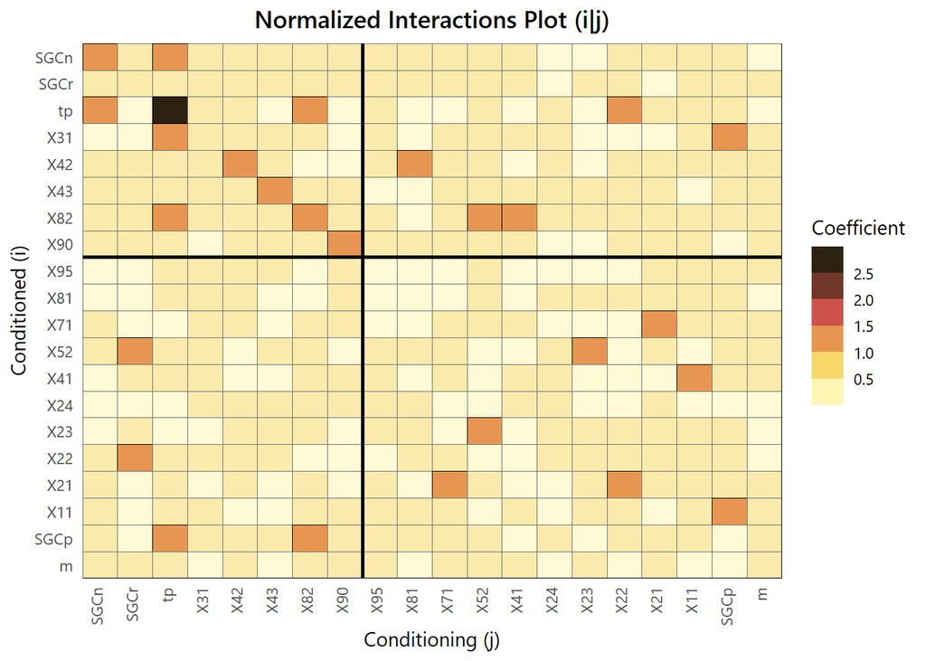

Based on the interactions plot, we have updated the list of significant parameters to include the following:

```
## [1] "SGCn" "SGCr" "tp"   "X31"  "X42"  "X43"  "X82"  "X90"
```

These parameters are shown in the top left corner of the plot.

# 5 Choose best-fit parameter values

The next step of this process is to determine the best-fit values for the significant (sensitive) parameters. All parameters classified as insignificant will be assigned their default values from the table at the top of this document.

All parameters were initially assumed to be uniformly distributed. We now take the top 1-10% of closest maps (by Hausdorff MDS) to the NFHL inundation map and look at how the distribution of sensitive parameters differs from the expected distribution. We assess the departure from uniform both visually and through the Kolmogorov-Smirnov (K-S) distribution test.

## 5.1 Inspect the original vs. updated parameter distributions

```r
## figure out which points are closest in MDS space
hd.dist <- map_dbl(.x = 1:n,
  .f = ~sqrt(sum((mds.hd$points[.x,1:mds.hd$dim90] -
                    mds.hd$points[n+1,1:mds.hd$dim90])^2)))

## decide how many clusters to consider (get to 10% of data)
n.clusters <-
  foreach (cl = 1:n, .combine = 'rbind') %do% {
    data.frame(mds.cluster = 1:n, dist = hd.dist) %>%
      arrange(dist) %>% .[1:cl,] %>%
      left_join(samples.rp100, by = 'mds.cluster') %>%
      nrow %>% c(cl, .)
    } %>%
  as.data.frame %>% setNames(c('mds.cluster', 'n.pts')) %>%
  filter(1:nrow(.) %in% 1:(which(n.pts>100)[1])) %>%
  pull(mds.cluster) %>% max

## find which distributions depart significantly from uniform
ks <-
  foreach (cl = 1:n, .combine = 'cbind') %do% {
    samples.subset <-
      data.frame(mds.cluster = 1:n, dist = hd.dist) %>%
      arrange(dist) %>% .[1:cl,] %>%
      left_join(samples.rp100, by = 'mds.cluster')
    d.crit <- 1.36 / sqrt(nrow(samples.subset))
    foreach (var = important, .combine = 'c') %do% {
      samples.subset %>%
        select(var) %>% arrange(get(var)) %>%
        mutate(p.var = punif(get(var), min = vars.df[which(var==vars), 'var.min'],
                         max = vars.df[which(var==vars), 'var.max']),
               p.unif = (1:nrow(samples.subset))/(nrow(samples.subset)+1)) %>%
        mutate(diff = abs(p.var - p.unif)) %>%
        mutate(ks = diff/d.crit) %>% arrange(desc(ks)) %>% pull(ks) %>% max
    }
  }
ks <- ks %>% as.data.frame %>%
  mutate(vars = important) %>%
  pivot_longer(cols = -vars, names_to = 'cl', values_to = 'ks') %>%
  mutate(cl = gsub('result.', '', cl) %>% toNumber)

# var <- 'tp'
# vmin <- vars.df[which(var==vars), 'var.min']
# vmax <- vars.df[which(var==vars), 'var.max']
# vmed <- vars.df[which(var==vars), 'default']
# lab <- vars.df[which(vars.df$vars == gsub('X', '', var)), 'description']
# for (cl in 1:n) {
#   samples.subset <-
#     data.frame(mds.cluster = 1:n, dist = hd.dist) %>%
#     arrange(dist) %>% .[1:cl,] %>%
#     left_join(samples.rp100, by = 'mds.cluster')
#   g <- ggplot() +
#     geom_rect(aes(xmin = vmin, xmax = vmax, ymin = 0, ymax = nrow(samples.subset)/8),
#               fill = 'black', alpha = 0.1) +
#     geom_histogram(data = samples.subset, aes(x = get(var)),
#                    color = 'black', fill = 'black', alpha = 0.2,
#                    breaks = seq(vmin, vmax, length.out = 9)) +
#     geom_vline(xintercept = vmed, linetype = 'dotted', size = 1) +
#     scale_x_continuous(paste0(gsub('X', '', var), ': ', lab)) +
#     scale_y_origin() +
#     theme(axis.title.y = element_blank())
#   print(g)
# }
```

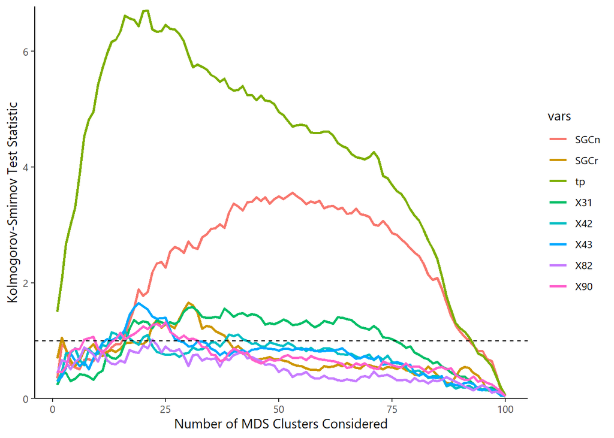

```r
## plot K-S test results
ggplot(ks) +
  geom_line(aes(x = cl, y = ks, group = vars, color = vars), size = 1) +
  geom_hline(yintercept = 1, linetype = 'dashed') +
  scale_x_continuous('Number of MDS Clusters Considered') +
  scale_y_origin('Kolmogorov-Smirnov Test Statistic')
```

```
## $`1`
```

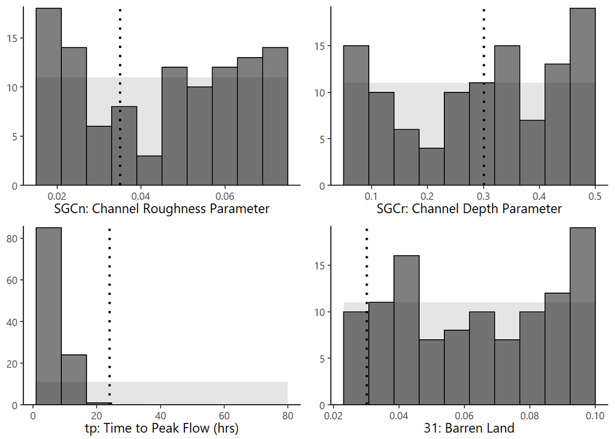

```
##
## $`2`
```

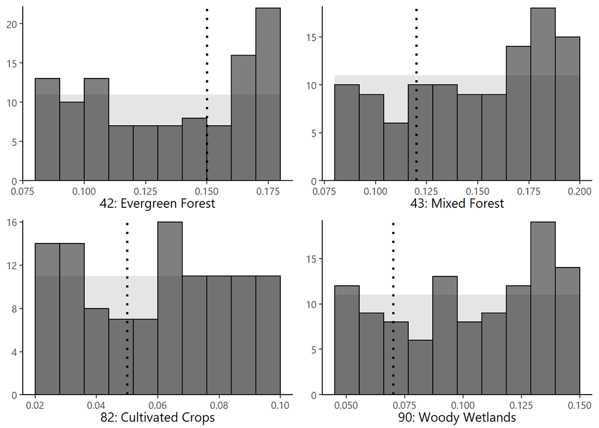

```
##
## attr(,"class")
## [1] "list"      "ggarrange"
```

```r
## plot individual parameter distributions
important.ks <- ks %>%
  filter(cl <= n/2) %>%
  group_by(vars) %>% summarize(ks.max = max(ks)) %>%
  filter(ks.max > 1) %>% pull(vars)
samples.subset <-
  data.frame(mds.cluster = 1:n, dist = hd.dist) %>%
  arrange(dist) %>% .[1:n.clusters,] %>%
  left_join(samples.rp100, by = 'mds.cluster')
important.plot <- lapply(important, function(var) {
  vmin <- vars.df[which(var==vars), 'var.min']
  vmax <- vars.df[which(var==vars), 'var.max']
  vmed <- vars.df[which(var==vars), 'default']
  lab <- vars.df[which(vars.df$vars == gsub('X', '', var)), 'description']
  ggplot() +
    geom_rect(aes(xmin = vmin, xmax = vmax, ymin = 0, ymax = nrow(samples.subset)/10),
              fill = 'black', alpha = 0.1) +
    geom_histogram(data = samples.subset, aes(x = get(var)),
                   color = 'black', fill = 'black',
                   alpha = ifelse(var %in% important.ks, 0.5, 0.2),
                   breaks = seq(vmin, vmax, length.out = 11)) +
    geom_vline(xintercept = vmed, linetype = 'dotted', size = 1) +
    scale_x_continuous(paste0(gsub('X', '', var), ': ', lab)) +
    scale_y_origin() +
    theme(axis.title.y = element_blank())})
do.call(ggarrange, c(important.plot, list(nrow = 2, ncol = 2)))
```

Calibration of Significant Parameters

| Senstitivity Parameters Name | Senstitivity Parameters Description | Values Default | Values New Value |
| --- | --- | --- | --- |
| Floodplain Roughness Parameters |  |  |  |
| 90 | Woody Wetlands | 0.070 | 0.13 |
| 82 | Cultivated Crops | 0.050 | 0.064 |
| 43 | Mixed Forest | 0.12 | 0.18 |
| 42 | Evergreen Forest | 0.15 | 0.18 |
| 31 | Barren Land | 0.030 | 0.096 |
| Channel Parameters |  |  |  |
| SGCn | Channel Roughness Parameter | 0.035 | 0.018 |
| SGCr | Channel Depth Parameter | 0.30 | 0.48 |
| Hydrograph Parameters |  |  |  |
| tp | Time to Peak Flow (hrs) | 24 | 5.0 |

# 6 Determine final accuracy

Last but not least, we determine the mismatch between our best-fit LISFLOOD inundation map and the FEMA NFHL 100-year floodplain map. We return to Sherlock to run one more simulation with the default + updated parameter values. The accuracy metrics and the spatial comparison for this “best-fit” simulation are shown below.

```r
bestfit <- raster('_sensitivity/rp100/sherlock/bestfit/bestfit.max') %>%
  overlay(dem.hydro, fun = function(x,y) ifelse(is.na(y), NA, x))

## calculate confusion matrix statistics
tb <- overlay(obs, bestfit, fun = confusion)[] %>% table

## report statistics
stats <-
  c(hitrate = unname(tb['0'] / (tb['-1'] + tb['0'])) %>%
      percent(accuracy = 0.1),
    falsalarm = unname(tb['1'] / (tb['0'] + tb['1'])) %>%
      percent(accuracy = 0.1),
    fstat = unname(tb['0'] / sum(tb)) %>%
      percent(accuracy = 0.1),
    bias = unname(tb['1'] / tb['-1']) %>%
      comma(accuracy = 0.01))
print(stats)
```

```
##   hitrate falsalarm     fstat      bias
##   "89.2%"   "36.3%"   "59.2%"    "4.67"
```

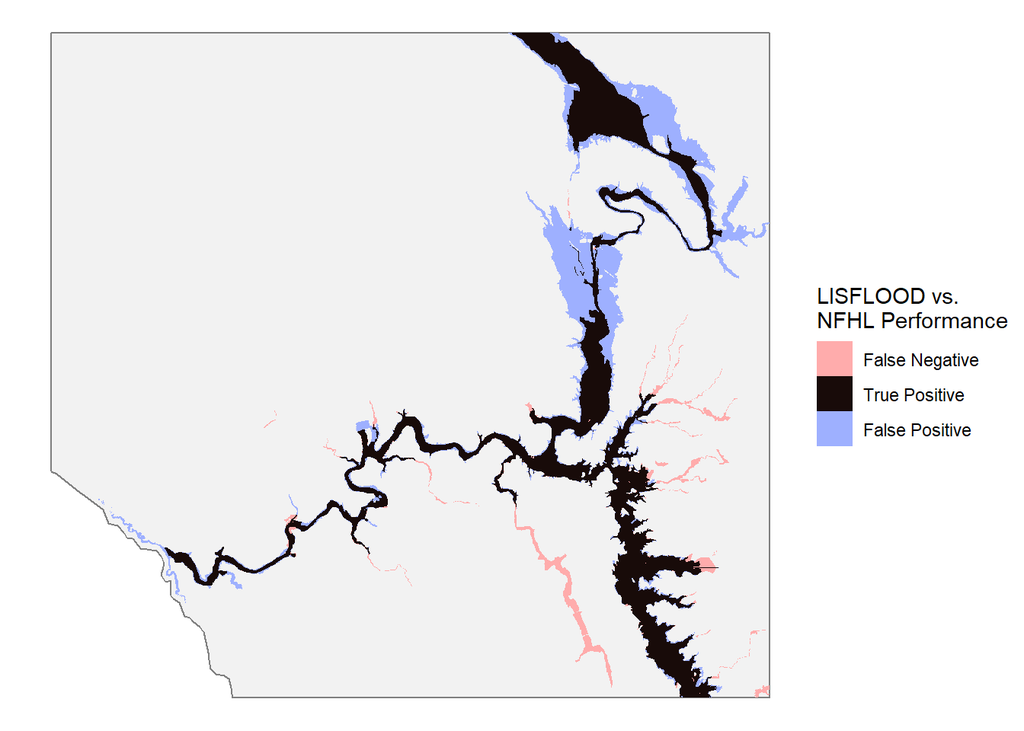

These accuracy statistics are very similar to the ones found by Wing et al. (2020) when comparing against the NFHL for the entire US. Therefore this is considered to be an acceptable fit, and we will use the LISFLOOD environment parameters calculated here for all further LISFLOOD modeling.